# QA masks for MODIS NDVI time series from Google Earth Engine

The MODIS vegetation product has a Summary QA band which has 4 values:

- 0: Good data, use with confidence
- 1: Marginal data, useful but look at detailed QA for more information
- 2: Pixel covered with snow/ice
- 3: Pixel is cloudy

It also has a DetailedQA band which is bit packed and gives more information about the pixel quality. Here we'll unpack the DetailedQA band to see.

This uses the gee_subset packge to query Google Earth Engine (GEE) for a single pixel timeseries across 6 years. To use it you'll need a GEE account.

- [GEE Info](https://developers.google.com/earth-engine/python_install)
- [gee_subset package](https://github.com/bluegreen-labs/gee_subset)

```python
import ee
from gee_subset.gee_subset import gee_subset
import pandas as pd
import seaborn as sns
import numpy as np
# ee.Authenticate()
ee.Initialize()

import unpackqa
```

```python
df = gee_subset(product    = 'MODIS/006/MOD13A1',
                bands      = ['NDVI','DetailedQA'],
                scale      = 500,
                start_date = '2015-01-01',
                end_date   = '2020-12-31',
                latitude   =   44.8166,
                longitude  = -114.8177,
                pad        =  0)
df.head()
```

|  | id | longitude | latitude | date | NDVI | DetailedQA | product |
| --- | --- | --- | --- | --- | --- | --- | --- |
| 0 | 2015_01_01 | -114.815922 | 44.814704 | 2015-01-01 | 806 | 18709 | MODIS/006/MOD13A1 |
| 1 | 2015_01_17 | -114.815922 | 44.814704 | 2015-01-17 | 2622 | 36330 | MODIS/006/MOD13A1 |
| 2 | 2015_02_02 | -114.815922 | 44.814704 | 2015-02-02 | 2578 | 2116 | MODIS/006/MOD13A1 |
| 3 | 2015_02_18 | -114.815922 | 44.814704 | 2015-02-18 | 2614 | 2441 | MODIS/006/MOD13A1 |
| 4 | 2015_03_06 | -114.815922 | 44.814704 | 2015-03-06 | 2470 | 2372 | MODIS/006/MOD13A1 |

First adjust the NDVI by the scaling factor and drop any NA values

```python
df['NDVI'] = df.NDVI * 0.0001
df = df[~df.NDVI.isna()].reset_index()
```

Values from GEE come in as floats, but unpackqa only works on integers. Here DetailedQA are 16-bits

```python
df['DetailedQA'] = df.DetailedQA.astype(np.uint16)

expanded_detailed_qa = unpackqa.unpack_to_dict(df.DetailedQA.values, product = 'MOD13Q1v006_DetailedQA', flags='all')
```

`unpack_to_dict` produces a dictionary where each key is a flag, and each value is an array the same length as the `df` data.frame. This can be converted directly to a new data.frame where the columns are the flag names, and then appended to the original data.frame.

```python
expanded_detailed_qa = pd.DataFrame(expanded_detailed_qa)
df = pd.concat([df, expanded_detailed_qa], axis=1)
df.head()
```

|  | index | id | longitude | latitude | date | NDVI | DetailedQA | product | VI_Quality | VI_Usefulness | Aerosol_Quantity | Adjacent_cloud_detected | Atmosphere_BRDF_Correction | Mixed_Clouds | Land_Water_Mask | Possible_snow_ice | Possible_shadow |
| --- | --- | --- | --- | --- | --- | --- | --- | --- | --- | --- | --- | --- | --- | --- | --- | --- | --- |
| 0 | 0 | 2015_01_01 | -114.815922 | 44.814704 | 2015-01-01 | 0.0806 | 18709 | MODIS/006/MOD13A1 | 1 | 5 | 0 | 1 | 0 | 0 | 1 | 1 | 0 |
| 1 | 1 | 2015_01_17 | -114.815922 | 44.814704 | 2015-01-17 | 0.2622 | 36330 | MODIS/006/MOD13A1 | 2 | 10 | 3 | 1 | 0 | 1 | 1 | 0 | 1 |
| 2 | 2 | 2015_02_02 | -114.815922 | 44.814704 | 2015-02-02 | 0.2578 | 2116 | MODIS/006/MOD13A1 | 0 | 1 | 1 | 0 | 0 | 0 | 1 | 0 | 0 |
| 3 | 3 | 2015_02_18 | -114.815922 | 44.814704 | 2015-02-18 | 0.2614 | 2441 | MODIS/006/MOD13A1 | 1 | 2 | 2 | 1 | 0 | 0 | 1 | 0 | 0 |
| 4 | 4 | 2015_03_06 | -114.815922 | 44.814704 | 2015-03-06 | 0.2470 | 2372 | MODIS/006/MOD13A1 | 0 | 1 | 1 | 1 | 0 | 0 | 1 | 0 | 0 |

Each pixel value in the time series now has the associated flags as columns.  
The `VI_Quality` flag has 4 values, where 0 signifies the best quality, 1 signifies a QA issue, 2 indicates likely clouds, and 3 indicates the pixel was not produced. Note in this instance there are no "not produced" pixels.

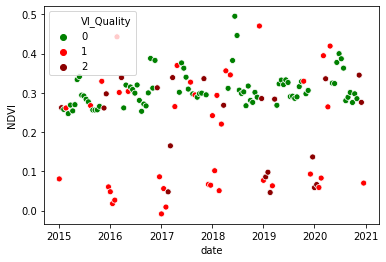

```python
colors = {0:'green',
          1:'red',
          2:'darkred',
          3:'black'}

sns.scatterplot(x='date',y='NDVI',hue='VI_Quality',data=df,palette=colors)
```

Other DetailedQA flags can give more insight into what it is affecting pixel quality. Here lets single out clouds, snow/ice, or cloud shadows.

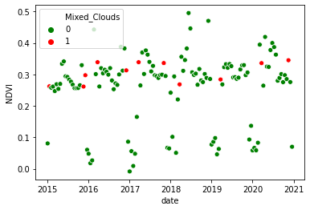

```python
colors = {0:'green',
          1:'red'}
sns.scatterplot(x='date',y='NDVI',hue='Mixed_Clouds',data=df,palette=colors)
```

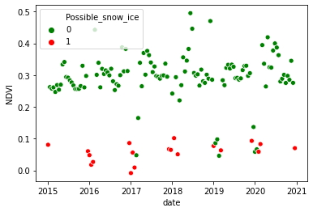

```python
sns.scatterplot(x='date',y='NDVI',hue='Possible_snow_ice',data=df,palette=colors)
```

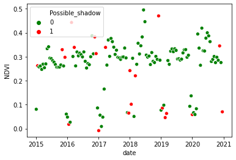

```python
sns.scatterplot(x='date',y='NDVI',hue='Possible_shadow',data=df,palette=colors)
```

Other quality issues may also be affecting it. Looking at the unique combinations of `VI_Quality` along with the other flags shows what is driving the final quality indicator.

```python
 df[['VI_Quality','Mixed_Clouds','Adjacent_cloud_detected','Possible_snow_ice','Possible_shadow','Atmosphere_BRDF_Correction']].drop_duplicates().sort_values('VI_Quality')
```

|  | VI_Quality | Mixed_Clouds | Adjacent_cloud_detected | Possible_snow_ice | Possible_shadow | Atmosphere_BRDF_Correction |
| --- | --- | --- | --- | --- | --- | --- |
| 2 | 0 | 0 | 0 | 0 | 0 | 0 |
| 43 | 0 | 0 | 0 | 0 | 1 | 0 |
| 4 | 0 | 0 | 1 | 0 | 0 | 0 |
| 0 | 1 | 0 | 1 | 1 | 0 | 0 |
| 68 | 1 | 0 | 0 | 1 | 1 | 0 |
| 24 | 1 | 0 | 1 | 1 | 1 | 0 |
| 23 | 1 | 0 | 0 | 1 | 0 | 0 |
| 14 | 1 | 0 | 0 | 0 | 0 | 0 |
| 3 | 1 | 0 | 1 | 0 | 0 | 0 |
| 19 | 1 | 0 | 1 | 0 | 1 | 0 |
| 20 | 2 | 1 | 0 | 0 | 0 | 0 |
| 95 | 2 | 0 | 1 | 0 | 1 | 0 |
| 28 | 2 | 1 | 0 | 0 | 1 | 0 |
| 49 | 2 | 0 | 0 | 0 | 0 | 0 |
| 1 | 2 | 1 | 1 | 0 | 1 | 0 |
| 74 | 2 | 1 | 1 | 0 | 0 | 0 |
| 93 | 2 | 0 | 0 | 0 | 1 | 0 |
| 116 | 2 | 0 | 1 | 0 | 0 | 0 |